# Modelos Lineares Generalizados - Poisson

Jose Storopoli

Saindo do universo dos modelos lineares, começamos a nos aventurar nos modelos linares generalizados (*generalized linear models* - GLM). O segundo deles é a regressão de Poisson.

Uma regressão de Poisson se comporta exatamente como um modelo linear: faz uma predição simplesmente computando uma soma ponderada das variáveis independentes, mais uma constante. Porém ao invés de retornar um valor contínuo, como a regressão linear, retorna o logarítmo natural desse valor.

$$\log(y)= \theta_0 + \theta_1 x_1 + \theta_2 x_2 + \dots + \theta_n x_n$$
que é o mesmo que

$$y = e^{(\theta_0 + \theta_1 x_1 + \theta_2 x_2 + \dots + \theta_n x_n)}$$
Regressão de Poisson é usada quando a nossa variável dependente só pode tomar valores positivos e discretos (número inteiros), geralmente em contextos de dados de contagem.

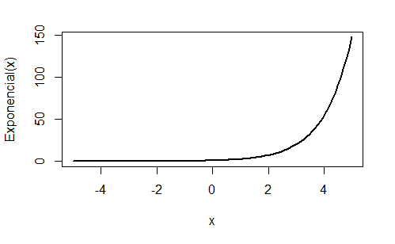

```r
x <- seq(-5, 5, length.out = 100)
plot(x, exp(x), type = "l", lwd=2, ylab = "Exponencial(x)")
```

## Regressão de Poisson com o `rstanarm`

O `rstanarm` pode tolerar qualquer modelo linear generalizado e regressão de Poisson não é uma exceção. Para rodar um modelo de Poisson no `rstanarm` é preciso simplesmente alterar o argumento `family` da função `stan_glm`.

Para exemplo, usaremos um *dataset* chamado `roaches` do pacote `rstanarm`. É uma base de dados com 262 observações sobre a eficácia de um sistema de controle de pragas em reduzir o número de baratas (*roaches*) em apartamentos urbanos.

Possui as seguintes variáveis:

- `y`: variável dependente - número de baratas mortas
- `roach1`: número de baratas antes da dedetização
- `treatment`: *dummy* para indicar se o apartamento foi dedetizado ou não
- `senior`: *dummy* para indicar se há apenas idosos no apartamento
- `exposure2`: número de dias que as armadilhas de baratas foram usadas

```r
options(mc.cores = parallel::detectCores())
options(Ncpus = parallel::detectCores())

library(rstanarm)
data(roaches)

model_poisson <- stan_glm(
  y ~ roach1 + treatment + senior,
  data = roaches,
  family = poisson()
    )
```

```r
summary(model_poisson)
```

```
Model Info:
 function:     stan_glm
 family:       poisson [log]
 formula:      y ~ roach1 + treatment + senior
 algorithm:    sampling
 sample:       4000 (posterior sample size)
 priors:       see help('prior_summary')
 observations: 262
 predictors:   4

Estimates:
              mean   sd   10%   50%   90%
(Intercept)  3.1    0.0  3.1   3.1   3.2
roach1       0.0    0.0  0.0   0.0   0.0
treatment   -0.5    0.0 -0.5  -0.5  -0.5
senior      -0.4    0.0 -0.4  -0.4  -0.3

Fit Diagnostics:
           mean   sd   10%   50%   90%
mean_PPD 25.6    0.4 25.1  25.6  26.2

The mean_ppd is the sample average posterior predictive distribution of the outcome variable (for details see help('summary.stanreg')).

MCMC diagnostics
              mcse Rhat n_eff
(Intercept)   0.0  1.0  3390
roach1        0.0  1.0  3834
treatment     0.0  1.0  3430
senior        0.0  1.0  3000
mean_PPD      0.0  1.0  3949
log-posterior 0.0  1.0  1858

For each parameter, mcse is Monte Carlo standard error, n_eff is a crude measure of effective sample size, and Rhat is the potential scale reduction factor on split chains (at convergence Rhat=1).
```

## Interpretação dos coeficientes

Ao vermos a fórmula de regressão de Poisson vemos que para analisarmos o efeito de um preditor na variável dependente temos que calcular o valor $e$ elevado ao coeficiente do preditor

$$y = e^{(\theta_0 + \theta_1 x_1 + \theta_2 x_2 + \dots + \theta_n x_n)}$$

```r
coeff <- exp(model_poisson$coefficients)
coeff
```

```
(Intercept)      roach1   treatment      senior
 23.0195194   1.0064672   0.5990271   0.6867653
```

## Priors

`rstanarm` possui as seguintes configurações como padrão de priors para regressão de Poisson:

- Constante (*Intercept*): centralizada com média $\mu = 0$ e desvio padrão de $2.5 \sigma_y$ - `prior_intercept = normal(0, 2.5 * sd_y)`
- Coeficientes: para cada coeficiente média $\mu = 0$ and standard deviation of $2.5\times\frac{1}{\sigma_{x_k}}$ - `prior = normal(0, 2.5 * 1/sd_xk)`
- Erro residual (`prior_aux`): uma distribuição exponencial com taxa $\frac{1}{\sigma_y}$: `prior_aux = exponential(1/sd_y)`

## Atividade Prática

Um *datasets* está disponível na pasta `datasets/`:

1. [New York City - East River Bicycle Crossings](https://www.kaggle.com/new-york-city/nyc-east-river-bicycle-crossings): `datasets/NYC_bicycle.csv`

```r
###
```